# Premières manipulations avec R: Corrigé

PC

2021

# 1 Exercice #1

1. Créer une liste de 3 éléments
2. Changer la valeur du deuxième élément de votre objet
3. Affecter à la liste les trois noms suivants : “A” , “B” et “C”
4. Ajouter un élément à votre liste
5. Nommer cet élément ajouté
6. Supprimer le troisième élément de cette liste
7. Afficher la liste finale et sa longueur

```r
#1
my_list <-  c("riri","fifi","loulou")
#2
my_list[2] <- "zaza"
#3
names(my_list) <-  c("A", "B", "C")
#4
my_list <- c(my_list, "donald")
#5
names(my_list)[4] <- "D"
#6
my_list <- my_list[-3]
#7
my_list # ou cat(my_list)
```

```
##        A        B        D
##   "riri"   "zaza" "donald"
```

```r
length(my_list)
```

```
## [1] 3
```

# 2 Exercice #2

0. Installer et charger le jeu de données du package `palmerpenguins`

```r
install.packages("palmerpenguins")
library(palmerpenguins )
```

Le jeu de données de ce package se nomme `penguins`

1. Quelles sont les variables de ce jeu de données ?

```r
names(penguins)
```

```
## [1] "species"           "island"            "bill_length_mm"
## [4] "bill_depth_mm"     "flipper_length_mm" "body_mass_g"
## [7] "sex"               "year"
```

2. Quel est le poids moyens des pingouins ?

```r
mean(penguins$body_mass_g, na.rm = T)
```

```
## [1] 4201.754
```

Il faut préciser l’argument `na.rm` à `TRUE` sinon le calcul échoue à cause des valeurs non attribuées.

3. Créer un dataframe qui ne contienne que les pingouins de l’espèce Gentoo

```r
gentoos <-  penguins[penguins$species =="Gentoo",]
```

Variante avec `dplyr`

```r
gentoos <-  filter(penguins, species =="Gentoo")
# variante avec l'opérateur %>%
gentoos <-  penguins %>% filter(species =="Gentoo")
```

4. Quelle est le poids moyen d’un pingouin Gentoo ?

```r
mean(gentoos$body_mass_g, na.rm = T)
```

```
## [1] 5076.016
```

5. Sur quelle(s) île(s) trouve-t-on les pingouins de l’espèce Adélie?

```r
penguinsAdelie <- penguins[penguins$species=="Adelie",]
islandsAdelie <- unique(penguinsAdelie$island)
islandsAdelie
```

```
## [1] Torgersen Biscoe    Dream
## Levels: Biscoe Dream Torgersen
```

6. Y-a-t’ il des autres pingouins que des pingouins Adélie sur les îles déterminées à la question 5 ?

```r
penguins[penguins$island %in% islandsAdelie,]
```

```
## # A tibble: 344 × 8
##    species island    bill_length_mm bill_depth_mm flipper_length_mm body_mass_g
##    <fct>   <fct>              <dbl>         <dbl>             <int>       <int>
##  1 Adelie  Torgersen           39.1          18.7               181        3750
##  2 Adelie  Torgersen           39.5          17.4               186        3800
##  3 Adelie  Torgersen           40.3          18                 195        3250
##  4 Adelie  Torgersen           NA            NA                  NA          NA
##  5 Adelie  Torgersen           36.7          19.3               193        3450
##  6 Adelie  Torgersen           39.3          20.6               190        3650
##  7 Adelie  Torgersen           38.9          17.8               181        3625
##  8 Adelie  Torgersen           39.2          19.6               195        4675
##  9 Adelie  Torgersen           34.1          18.1               193        3475
## 10 Adelie  Torgersen           42            20.2               190        4250
## # … with 334 more rows, and 2 more variables: sex <fct>, year <int>
```

Oui !

# 3 Exercice #3

1. Écrire une fonction qui prend en argument un vecteur de valeurs numériques et qui le centre et le réduit , c’est-à-dire qui soustrait à chaque valeur la moyenne du vecteur et qui divise par la valeur de l’écart-type . Vous pouvez tester votre fonction avec un vecteur initialisé par vos soins, un dataframe de votre choix ou le dataframe `iris`.

```r
center_reduce <-  function(v){
  m <-  mean(v)
  s <-  sd(v)
  result <-  (v - m) / s
  return(result)
}
```

Test de la fonction sur `iris$Sepal.Length`

```r
center_reduce(iris$Sepal.Length)
```

```
##   [1] -0.89767388 -1.13920048 -1.38072709 -1.50149039 -1.01843718 -0.53538397
##   [7] -1.50149039 -1.01843718 -1.74301699 -1.13920048 -0.53538397 -1.25996379
##  [13] -1.25996379 -1.86378030 -0.05233076 -0.17309407 -0.53538397 -0.89767388
##  [19] -0.17309407 -0.89767388 -0.53538397 -0.89767388 -1.50149039 -0.89767388
##  [25] -1.25996379 -1.01843718 -1.01843718 -0.77691058 -0.77691058 -1.38072709
##  [31] -1.25996379 -0.53538397 -0.77691058 -0.41462067 -1.13920048 -1.01843718
##  [37] -0.41462067 -1.13920048 -1.74301699 -0.89767388 -1.01843718 -1.62225369
##  [43] -1.74301699 -1.01843718 -0.89767388 -1.25996379 -0.89767388 -1.50149039
##  [49] -0.65614727 -1.01843718  1.39682886  0.67224905  1.27606556 -0.41462067
##  [55]  0.79301235 -0.17309407  0.55148575 -1.13920048  0.91377565 -0.77691058
##  [61] -1.01843718  0.06843254  0.18919584  0.30995914 -0.29385737  1.03453895
##  [67] -0.29385737 -0.05233076  0.43072244 -0.29385737  0.06843254  0.30995914
##  [73]  0.55148575  0.30995914  0.67224905  0.91377565  1.15530226  1.03453895
##  [79]  0.18919584 -0.17309407 -0.41462067 -0.41462067 -0.05233076  0.18919584
##  [85] -0.53538397  0.18919584  1.03453895  0.55148575 -0.29385737 -0.41462067
##  [91] -0.41462067  0.30995914 -0.05233076 -1.01843718 -0.29385737 -0.17309407
##  [97] -0.17309407  0.43072244 -0.89767388 -0.17309407  0.55148575 -0.05233076
## [103]  1.51759216  0.55148575  0.79301235  2.12140867 -1.13920048  1.75911877
## [109]  1.03453895  1.63835547  0.79301235  0.67224905  1.15530226 -0.17309407
## [115] -0.05233076  0.67224905  0.79301235  2.24217198  2.24217198  0.18919584
## [121]  1.27606556 -0.29385737  2.24217198  0.55148575  1.03453895  1.63835547
## [127]  0.43072244  0.30995914  0.67224905  1.63835547  1.87988207  2.48369858
## [133]  0.67224905  0.55148575  0.30995914  2.24217198  0.55148575  0.67224905
## [139]  0.18919584  1.27606556  1.03453895  1.27606556 -0.05233076  1.15530226
## [145]  1.03453895  1.03453895  0.55148575  0.79301235  0.43072244  0.06843254
```

2. Afficher l’histogramme du vecteur centré et réduit.

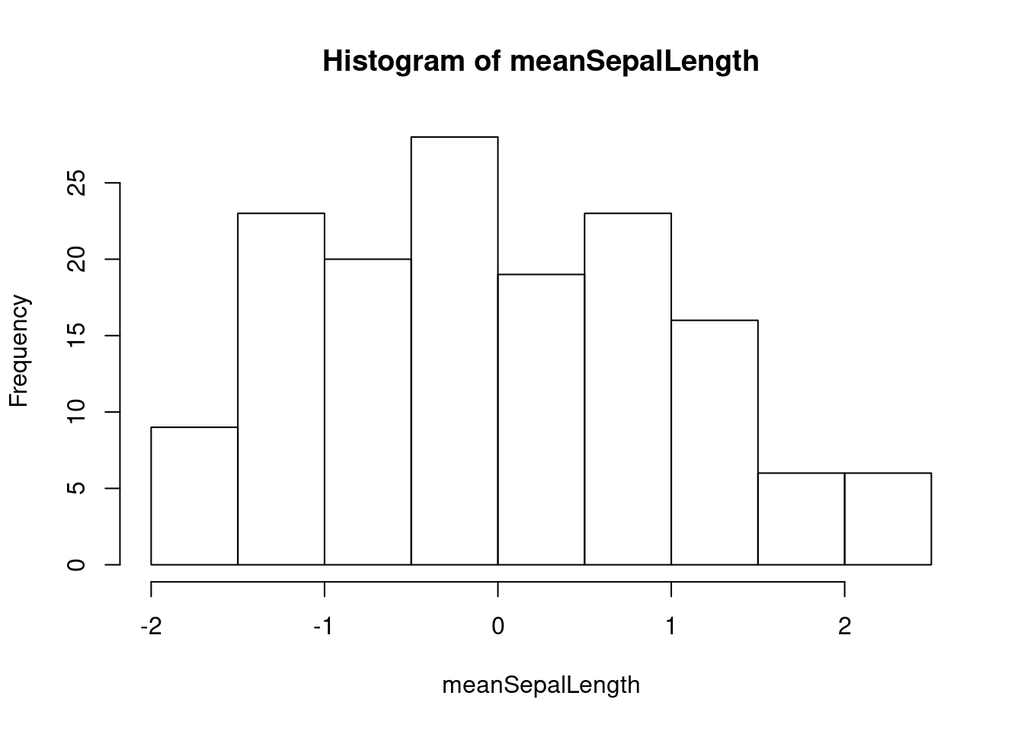

```r
meanSepalLength <- center_reduce(iris$Sepal.Length)
hist(meanSepalLength)
```

# 4 Exercice #4

1. Récupérer les données

Récupérer le fichier `2020_LoL_esports_match_data_from_OraclesElixir_20210124.csv` sur le répertoire partagé de la formation.

Il s’agit de résultats d’une compétition d’e-sport sur le jeu “Leagues of Legend”, qui oppose deux équipes de 5 joueurs. La connaissance du jeu lui même n’est pas nécessaire pour répondre aux questions.^ Une ligne contient les variables qui décrivent **un** match d’**un** joueur

Pour les questions suivantes, faites figurer dans un script R le code qui vous permet de réaliser les étapes suivantes :

2. Lire le fichier

```r
loldata <- read.csv("./2020_LoL_esports_match_data_from_OraclesElixir_20210124.csv")
```

3. Identifier le nombre de colonnes et de lignes du fichier

```r
nrow(loldata)
```

```
## [1] 86803
```

```r
ncol(loldata)
```

```
## [1] 117
```

```r
# affichage formatté
cat(nrow(loldata), "lignes et ", ncol(loldata), "colonnes.")
```

```
## 86803 lignes et  117 colonnes.
```

4. Quel est le type de la colonne `position` et de la colonne `dpm` du jeu de données ?

```r
class(loldata$position)
```

```
## [1] "factor"
```

```r
class(loldata$dpm)
```

```
## [1] "numeric"
```

5. Calculer la valeur moyenne de la colonne `totalgold`

```r
mean(loldata$totalgold)
```

```
## [1] 18854.25
```

6. A partir du jeu de données initial, on vous demande de créer un second dataframe qui ne contienne que les données des joueurs qui ont perdu les matchs de la compétition . Dans les données , c’est la colonne `result` qui porte cette information, la valeur `0` signifiant une défaite.

```r
loosers <-  loldata %>%  filter(result==0)
```

7. Sauvegarder le résultat dans un fichier que vous appelez “defeats.csv”

```r
write.csv(loosers, "defeats.csv")
```

8. Les données sur les matches contiennent une colonne `totalgold` (l’or gagné par les joueurs au courts d’un match) et une colonne `gamelength` qui indique la durée du match en secondes. Créer une fonction qui calcule le nombre de d’unité de “gold” par minute à partir d’une durée en secondes et d’une quantité de `totalgold`.

```r
compute_gold_by_minute <-  function(gold, time){
  minutes <-  time/60
  return(gold/minutes)
}
```

9. Ajouter une colonne intitulée `gold_per_min`au dataframe, qui contienne la quantité de `gold` obtenue par minute, calculée sur toutes les données à l’aide de votre fonction.

```r
loldata$gold_per_min <- compute_gold_by_minute(loldata$totalgold, loldata$gamelength)
```

10. Appliquer (et éventuellement adapter) la fonction créée en 8. sur les données de matches avec les colonnes `kills` et `gamelength`, et ajouter une colonne qui s’intitule `kill_per_min`.

Variante 1 : on réécrit la fonction

```r
compute_kill_by_min <-  function(kills, time){
  return(kills/ (time/60))
}
loldata$kill_per_min <- compute_kill_by_min(loldata$kills, loldata$gamelength)
```

Variante 2 : on applique la fonction `compute_gold_by_min` en remplaçant les arguments

```r
loldata$kill_per_min <- compute_gold_by_minute(loldata$kills, loldata$gamelength)
```

Variante 3 : calcul direct

```r
loldata$kill_per_min <- loldata$kills / (loldata$gamelength/60)
```

11. Tracer le nuage de points qui représente les deux variables nouvellement crées : `gold_per_min`et `kill_per_min`

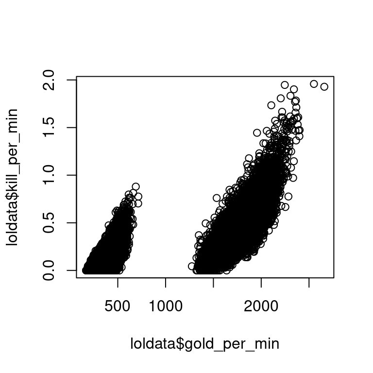

```r
plot(x = loldata$gold_per_min, y=loldata$kill_per_min)
```

Variante avec ggplot

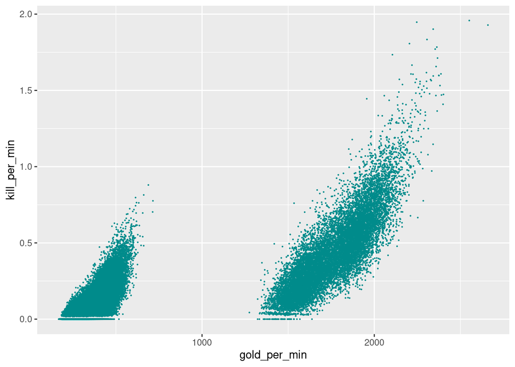

```r
library(ggplot2)
myplot <- ggplot(loldata, aes(x=gold_per_min, y=kill_per_min))+
                     geom_point(color="darkcyan", size=.1)
myplot
```

12. Optionnel : Envoyer le code (si vous voulez une correction spécifique)

# 5 Exercice #5

Implémentez en R le [crible d’ératosthène](https://fr.wikipedia.org/wiki/Crible_d%27%C3%89ratosth%C3%A8ne)

```r
limite <-  200
isprime <-  rep(TRUE, limite)
isprime[1] <-  FALSE
isprime[seq(from=4, to=limite, by=2)] <- FALSE

i <-  3
while (i*i < limite) {
  if(isprime[i]){
    for (j in seq(from=i*i, to=limite, by=2*i ) ) {
      isprime[j] <-  FALSE
    }
  }
  i <-  i+1
}

numbers <-  seq(from=1, to=200, by=1)
prime_numbers <-numbers[isprime]
prime_numbers
```

```
##  [1]   2   3   5   7  11  13  17  19  23  29  31  37  41  43  47  53  59  61  67
## [20]  71  73  79  83  89  97 101 103 107 109 113 127 131 137 139 149 151 157 163
## [39] 167 173 179 181 191 193 197 199
```

Vous pouvez vous inspirer du pseudo code suivant :

```
Fonction Eratosthène(Limite)
   L = tableau de booléen de taille Limite, initialisé à Vrai
   Mettre à Faux les cases d'indice pair > 2
   L[1] = Faux
   i=3
   Tant que i*i≤Limite
       Si L[i]
           Pour j de i*i à Limite par pas de 2*i
               L[j] = Faux
           Fin pour
       Fin si
       i=i+1
   Fin tant que
   Retourner L
Fin fonction
```